# Ford scholars alumni survey

# Demographics

In total, there were 314 respondents.

## Type of scholarship

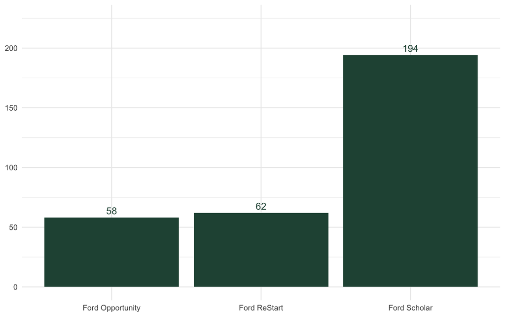

## Where do respondents live?

### All respondents

Note: Respondents who listed the exact same zip codes are spread out slightly so they don’t overlap. The dots do not show not exact locations of respondents.

[interactive chart not shown]

### Within Oregon vs outside Oregon

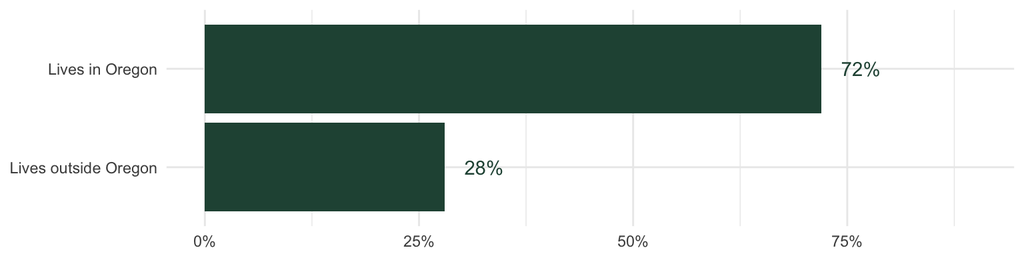

### By Oregon county

This map shows the number of respondents per county (it only shows those who live in Oregon, obviously). Darker colors indicate higher numbers in a county. Hover over any county to see the exact number of respondents.

[interactive chart not shown]

### Rural

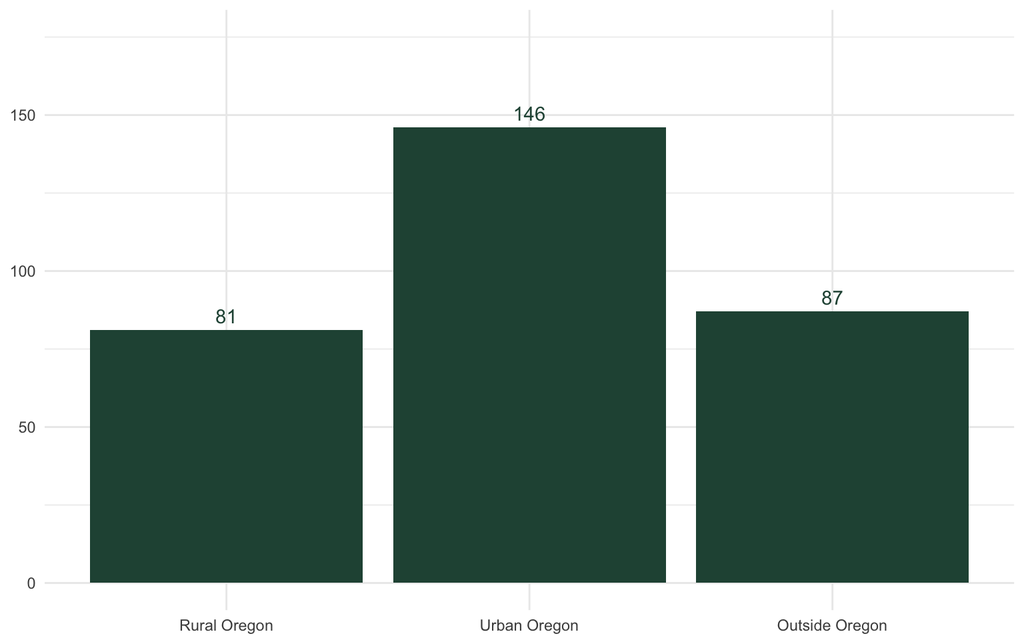

## Age

Age of all respondents

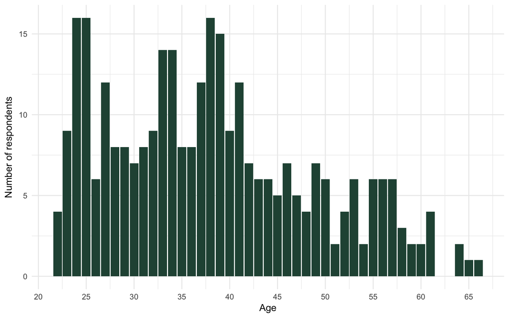

Age of all respondents, grouped by decade

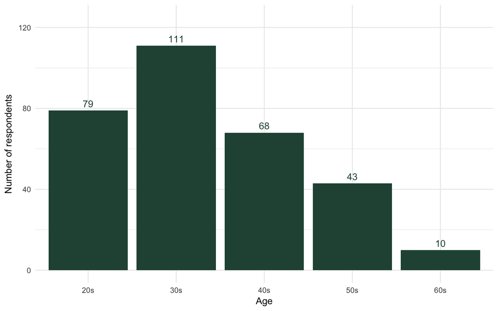

## Education

### Year respondents graduated from college

Note that some people were confused by whether to count their undergrad or higher levels. I only included answers that were clearly for undregrad.

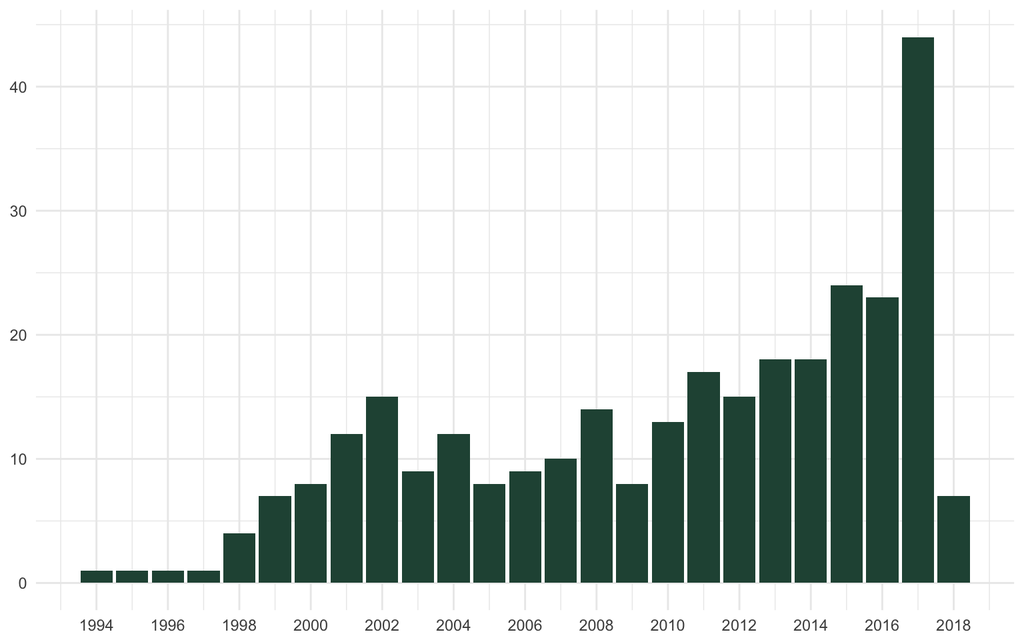

### Years since graduation

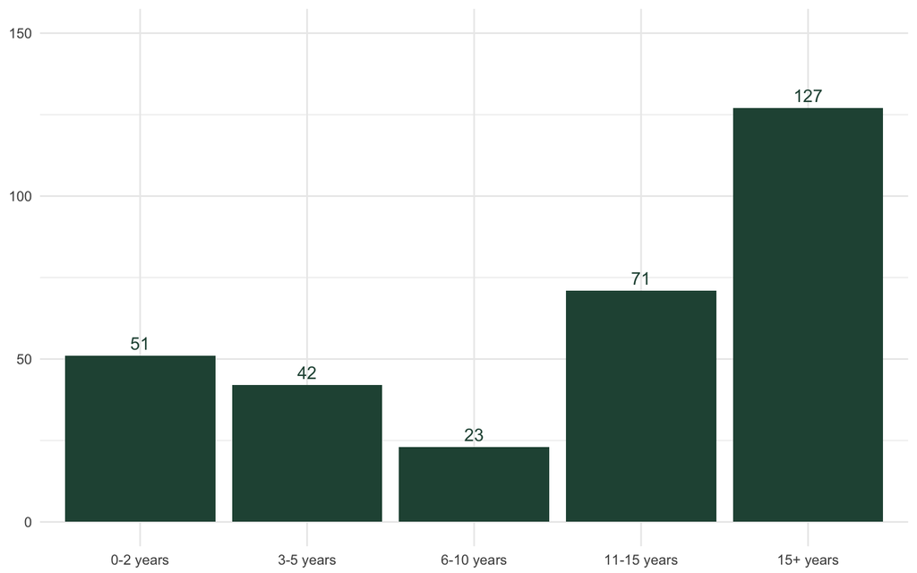

### Highest level of education

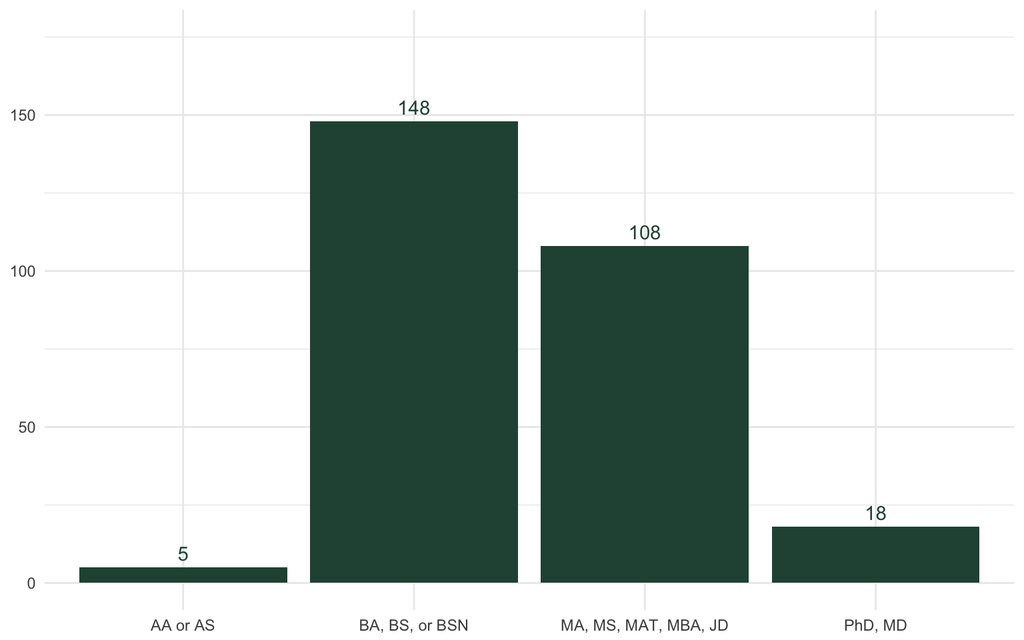

## Work

Principal industry (does not include those who said NA or listed other as their response).

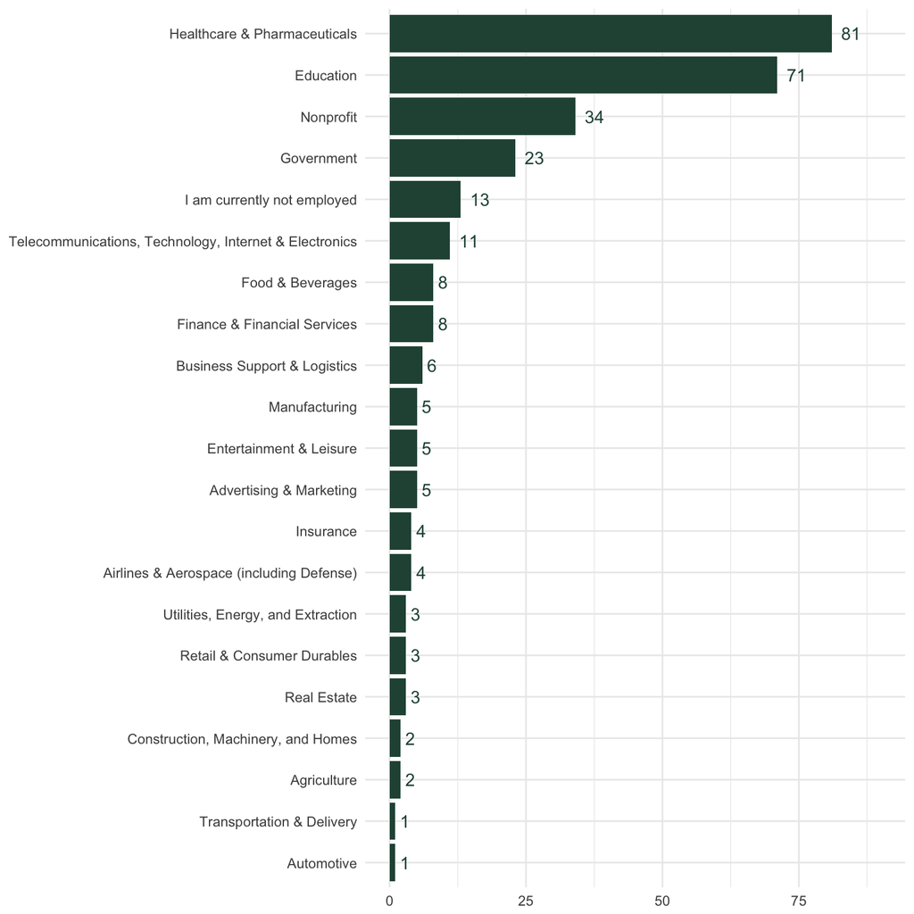

# Communications

## Prior to receiving the email for this survey, were you aware of the existence of the Ford Scholar Alumni Association?

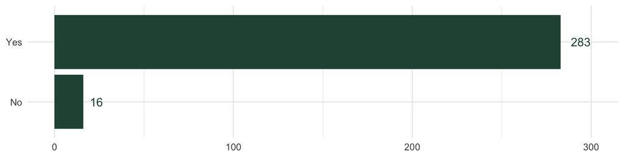

## Which communications from the alumni association do you currently receive?

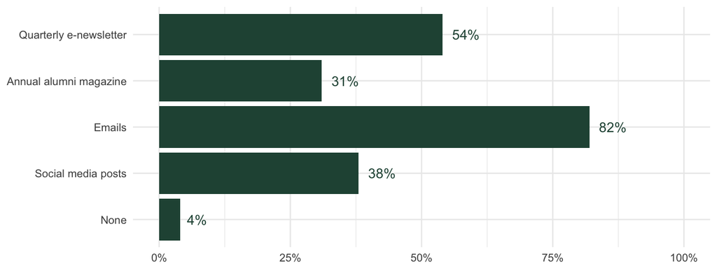

## How helpful are the following methods of the FSAA’s communications?

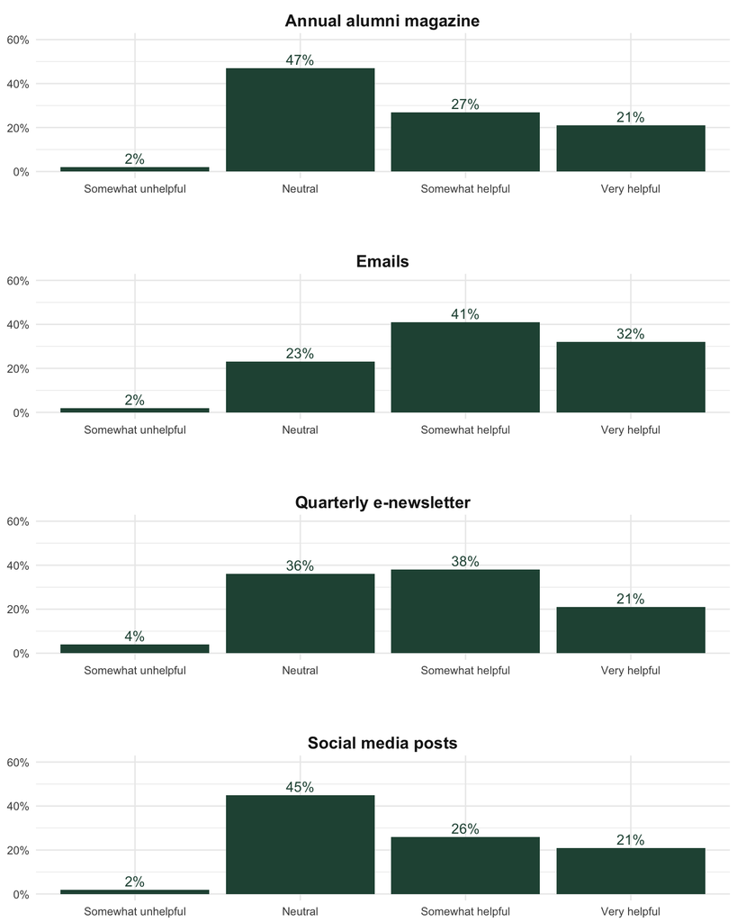

## Rank the type of information you would like to see in alumni association communications, where 1 is the information you would most like to see and 6 is is the information you would least like to see.

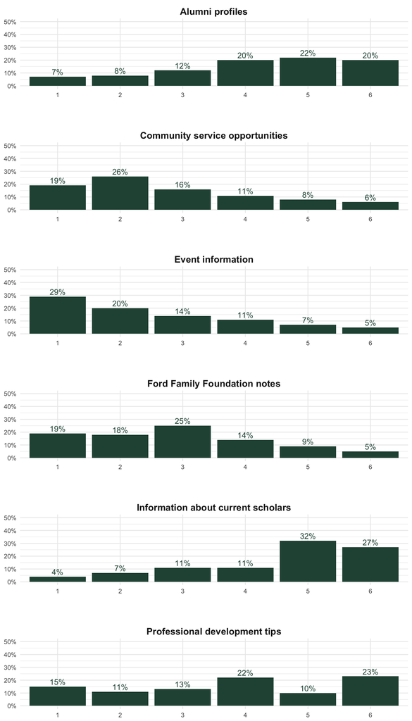

# Engagement

## How likely would you be to participate in the following types of opportunities if they were available?

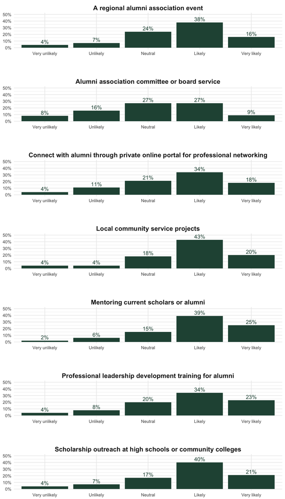

## Rank from most important to least, from your perspective, the following reasons for engaging with the alumni association.

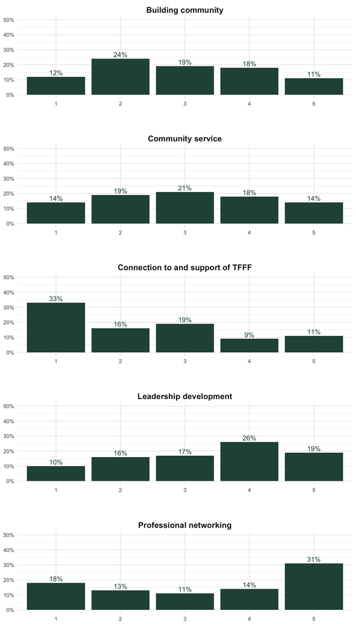

## Have you participated in past alumni association events?

[figure not shown]

# The Ford Family Foundation

## How interested are you in engaging with the alumni association?

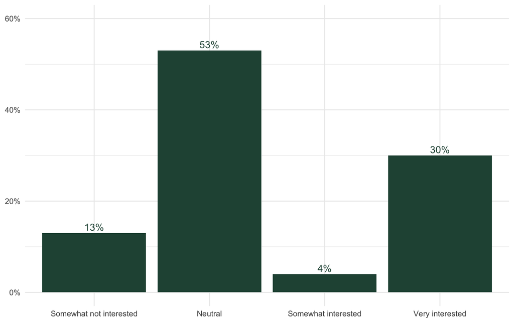

## How interested are you in being engaged with The Ford Family Foundation?

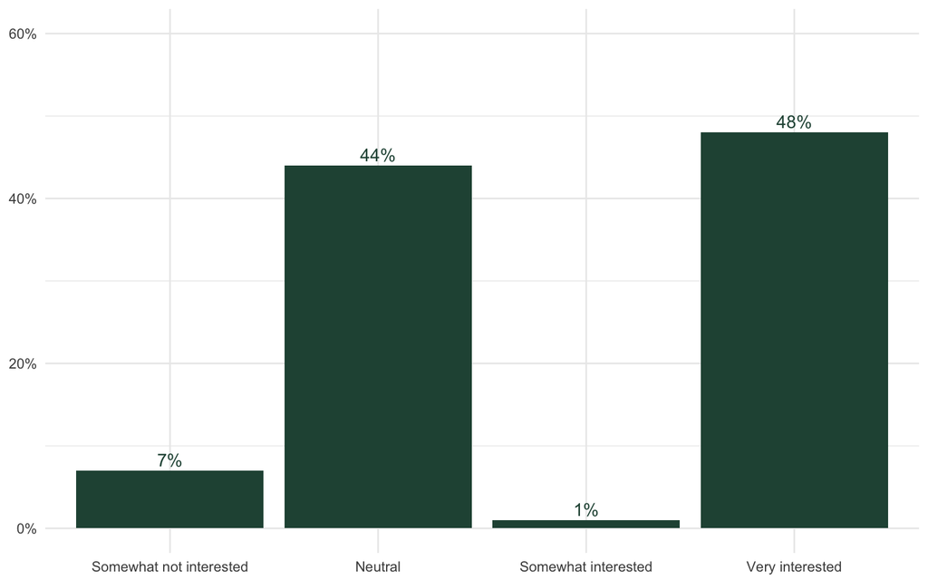

## How aware are you about the work of the departments at The Ford Family Foundation?

[figure not shown]